# Incidence, Risk Factors for and Outcomes of Transplant-Associated Thrombotic Microangiopathy

# 1. Import Libraries

```r
# Load required packages from the tidyverse and additional libraries
library(tidyverse)       # Data manipulation and visualization
library(caret)           # Data partitioning and model evaluation
library(gridExtra)       # Plot arrangement
library(DMwR)            # SMOTE for imbalanced data handling
library(Boruta)          # Feature selection
library(Epi)             # ROC optimal threshold determination
library(ggcorrplot)      # Correlation visualization
library(dplyr)           # Data manipulation (subset of tidyverse)
library(haven)           # Importing SAS datasets
library(GGally)          # Pair plots
library(rsample)         # Resampling, splitting data
library(pROC)            # ROC analysis
library(car)             # Variance inflation factor (VIF)
library(reshape2)        # Data reshaping for plots
library(survival)        # Survival analysis functions
library(survminer)       # Enhanced survival plots
```

# 2. Load and Explore the Dataset

```r
# Read the SAS dataset
df <- read_sas("RT14-02.sas7bdat")

# Quick look at the data
head(df)
```

| yeartx | sex | plsmpshi | age | intxsurv | drabomatch | intxtma | renfail | intxrenfail | karnofcat | diseasegp | atgcampathgp | graftgp | racegp | hctcigp | drcmvgp | priautogp | dead | dworenfail | condgp | kidfunc | agvhd24 | agvhd34 | dwoagvhd24 | dwoagvhd34 | intxagvhd24 | intxagvhd34 | death_gp | dnrtype | gvhd_gp | … |
| --- | --- | --- | --- | --- | --- | --- | --- | --- | --- | --- | --- | --- | --- | --- | --- | --- | --- | --- | --- | --- | --- | --- | --- | --- | --- | --- | --- | --- | --- | --- |
| 2009 | 2 | 0 | 44 | 1.61 | 2 | 1.38 | 0 | 1.38 | 1 | 1 | 2 | 2 | 1 | 99 | 1 | 1 | 1 | 1 | 1 | 1 | 0 | 0 | 0 | 0 | 1.38 | 1.38 | 2 | 4 | 5 | … |
| 2009 | 1 | 0 | 14 | 9.18 | 1 | 9.18 | 0 | 9.18 | 1 | 4 | 2 | 1 | 1 | 99 | 2 | 0 | 1 | 1 | 1 | 1 | 0 | 0 | 1 | 1 | 9.18 | 9.18 | 3 | 5 | 5 | … |
| 2009 | 1 | 0 | 26 | 7.80 | 0 | 7.80 | 0 | 7.80 | 1 | 5 | 2 | 1 | 2 | 99 | 3 | 0 | 1 | 1 | 1 | 1 | 1 | 1 | 0 | 0 | 0.76 | 0.76 | 4 | 5 | 5 | … |
| 2008 | 2 | 0 | 12 | 6.97 | 0 | 1.71 | 1 | 1.58 | 1 | 2 | 4 | 3 | 1 | 3 | 1 | 0 | 1 | 0 | 1 | 1 | 0 | 0 | 0 | 0 | 1.71 | 1.71 | 5 | 13 | 2 | … |
| 2008 | 1 | 0 | 7 | 96.02 | 0 | 4.80 | 0 | 96.02 | 1 | 7 | 4 | 3 | 3 | 0 | 1 | 0 | 0 | 0 | 1 | 1 | 1 | 1 | 0 | 0 | 0.79 | 0.79 | 0 | 14 | 5 | … |
| 2009 | 2 | 0 | 15 | 6.94 | 0 | 6.94 | 0 | 6.94 | 1 | 1 | 4 | 3 | 1 | 0 | 1 | 0 | 1 | 1 | 1 | 1 | 1 | 0 | 0 | 1 | 0.49 | 6.94 | 1 | 12 | 5 | … |

```r
str(df)
```

```
tibble [23,090 × 35] (S3: tbl_df/tbl/data.frame)
 $ yeartx      : num [1:23090] 2009 2009 2009 2008 2008 ...
  ..- attr(*, "label")= chr "Year of transplant"
 $ sex         : num [1:23090] 2 1 1 2 1 2 2 2 1 2 ...
  ..- attr(*, "label")= chr "Sex"
 $ plsmpshi    : num [1:23090] 0 0 0 0 0 0 0 0 0 0 ...
  ..- attr(*, "label")= chr "Received plasmapheresis as treatment for TA-TMA"
 $ age         : num [1:23090] 44 14 26 12 7 15 13 14 4 9 ...
  ..- attr(*, "label")= chr "Patient age"
 $ intxsurv    : num [1:23090] 1.61 9.18 7.8 6.97 96.02 ...
  ..- attr(*, "label")= chr "Time from HCT to death/last follow-up date"
 $ drabomatch  : num [1:23090] 2 1 0 0 0 0 2 2 0 1 ...
  ..- attr(*, "label")= chr "Donor/recipient ABO match"
 $ intxtma     : num [1:23090] 1.38 9.18 7.8 1.71 4.8 ...
  ..- attr(*, "label")= chr "Time from transplant to TA-TMA or last contact, months"
 $ renfail     : num [1:23090] 0 0 0 1 0 0 0 1 0 99 ...
  ..- attr(*, "label")= chr "Renal failure requiring diaylsis"
 $ intxrenfail : num [1:23090] 1.38 9.18 7.8 1.58 96.02 ...
  ..- attr(*, "label")= chr "Time from transplant to renal failure requiring dialysis or last contact, months"
 $ karnofcat   : num [1:23090] 1 1 1 1 1 1 2 1 1 1 ...
  ..- attr(*, "label")= chr "Karnofsky performance score"
 $ diseasegp   : num [1:23090] 1 4 5 2 7 1 13 1 1 2 ...
  ..- attr(*, "label")= chr "Disease"
 $ atgcampathgp: num [1:23090] 2 2 2 4 4 4 2 4 2 4 ...
  ..- attr(*, "label")= chr "ATG/Campath"
 $ graftgp     : num [1:23090] 2 1 1 3 3 3 1 3 3 3 ...
  ..- attr(*, "label")= chr "Graft type"
 $ racegp      : num [1:23090] 1 1 2 1 3 1 1 2 1 1 ...
  ..- attr(*, "label")= chr "Patient race"
 $ hctcigp     : num [1:23090] 99 99 99 3 0 0 1 0 0 0 ...
  ..- attr(*, "label")= chr "HCT-CI (excluding renal condition)"
 $ drcmvgp     : num [1:23090] 1 2 3 1 1 1 1 3 1 4 ...
  ..- attr(*, "label")= chr "Donor-recipient CMV status"
 $ priautogp   : num [1:23090] 1 0 0 0 0 0 0 0 0 0 ...
  ..- attr(*, "label")= chr "Prior autologous transplant"
 $ dead        : num [1:23090] 1 1 1 1 0 1 0 1 0 0 ...
  ..- attr(*, "label")= chr "Overall survival"
 $ dworenfail  : num [1:23090] 1 1 1 0 0 1 0 0 0 0 ...
  ..- attr(*, "label")= chr "Death without renal failure requiring dialysis"
 $ condgp      : num [1:23090] 1 1 1 1 1 1 4 1 2 1 ...
```

[output cut: 16 more lines]

```
  ..- attr(*, "label")= chr "Main cause of death"
 $ dnrtype     : num [1:23090] 4 5 5 13 14 12 1 12 11 12 ...
  ..- attr(*, "label")= chr "Donor type"
 $ gvhd_gp     : num [1:23090] 5 5 5 2 5 5 4 6 5 5 ...
  ..- attr(*, "label")= chr "GVHD prophylaxis"
 $ orgfail     : num [1:23090] 99 99 99 1 99 99 99 1 99 99 ...
  ..- attr(*, "label")= chr "Type of organ failure, among organ failure as cause of death"
 $ malig_grp   : num [1:23090] 1 1 1 1 1 1 2 1 1 1 ...
  ..- attr(*, "label")= chr "Malignant vs. Non-malignant disease"
 $ agvhdgp     : num [1:23090] 0 0 2 0 2 1 0 0 0 0 ...
  ..- attr(*, "label")= chr "Acute GVHD grade"
 $ tma_event   : num [1:23090] 0 0 0 0 1 0 0 0 0 0 ...
  ..- attr(*, "label")= chr "TA-TMA (transplant-associated thrombotic microangiopathy)"
 $ pseudoid    : num [1:23090] 61488133 61673027 61682387 61818265 61800746 ...
  ..- attr(*, "label")= chr "De-identified patient ID"
```

```r
summary(df)
```

```
     yeartx          sex           plsmpshi            age
 Min.   :2008   Min.   :1.000   Min.   : 0.0000   Min.   : 0.00
 1st Qu.:2009   1st Qu.:1.000   1st Qu.: 0.0000   1st Qu.:23.00
 Median :2013   Median :1.000   Median : 0.0000   Median :49.00
 Mean   :2012   Mean   :1.412   Mean   : 0.3114   Mean   :42.04
 3rd Qu.:2015   3rd Qu.:2.000   3rd Qu.: 0.0000   3rd Qu.:60.00
 Max.   :2016   Max.   :2.000   Max.   :99.0000   Max.   :83.00

    intxsurv        drabomatch        intxtma          renfail
 Min.   :  0.00   Min.   : 0.000   Min.   :  0.00   Min.   : 0.00
 1st Qu.:  5.99   1st Qu.: 0.000   1st Qu.:  5.49   1st Qu.: 0.00
 Median : 13.85   Median : 0.000   Median : 12.60   Median : 0.00
 Mean   : 27.00   Mean   : 3.482   Mean   : 25.45   Mean   : 4.29
 3rd Qu.: 37.60   3rd Qu.: 2.000   3rd Qu.: 36.45   3rd Qu.: 0.00
 Max.   :109.80   Max.   :99.000   Max.   :108.42   Max.   :99.00
                                   NA's   :23
  intxrenfail       karnofcat        diseasegp       atgcampathgp
 Min.   :-11.61   Min.   : 1.000   Min.   : 1.000   Min.   :1.00
 1st Qu.:  5.43   1st Qu.: 1.000   1st Qu.: 1.000   1st Qu.:2.00
 Median : 12.80   Median : 1.000   Median : 3.000   Median :4.00
 Mean   : 25.88   Mean   : 3.299   Mean   : 4.365   Mean   :3.33
 3rd Qu.: 36.80   3rd Qu.: 2.000   3rd Qu.: 6.000   3rd Qu.:4.00
 Max.   :108.42   Max.   :99.000   Max.   :15.000   Max.   :4.00
 NA's   :1003
    graftgp          racegp          hctcigp          drcmvgp
 Min.   :1.000   Min.   : 1.000   Min.   : 0.000   Min.   : 1.000
 1st Qu.:2.000   1st Qu.: 1.000   1st Qu.: 0.000   1st Qu.: 1.000
 Median :2.000   Median : 1.000   Median : 2.000   Median : 3.000
 Mean   :2.003   Mean   : 5.141   Mean   : 4.131   Mean   : 5.083
 3rd Qu.:2.000   3rd Qu.: 1.000   3rd Qu.: 3.000   3rd Qu.: 4.000
 Max.   :3.000   Max.   :99.000   Max.   :99.000   Max.   :99.000

   priautogp            dead           dworenfail         condgp
 Min.   : 0.0000   Min.   : 0.0000   Min.   : 0.000   Min.   : 1.00
 1st Qu.: 0.0000   1st Qu.: 0.0000   1st Qu.: 0.000   1st Qu.: 2.00
 Median : 0.0000   Median : 0.0000   Median : 0.000   Median : 2.00
 Mean   : 0.5827   Mean   : 0.4918   Mean   : 1.493   Mean   : 2.78
 3rd Qu.: 0.0000   3rd Qu.: 1.0000   3rd Qu.: 1.000   3rd Qu.: 4.00
 Max.   :99.0000   Max.   :99.0000   Max.   :99.000   Max.   :99.00

```

[output cut: 16 more lines]

```
    dnrtype          gvhd_gp         orgfail       malig_grp
 Min.   : 1.000   Min.   :1.000   Min.   : 1.0   Min.   :1.000
 1st Qu.: 1.000   1st Qu.:4.000   1st Qu.:99.0   1st Qu.:1.000
 Median : 4.000   Median :4.000   Median :99.0   Median :1.000
 Mean   : 5.114   Mean   :4.066   Mean   :91.3   Mean   :1.119
 3rd Qu.: 5.000   3rd Qu.:5.000   3rd Qu.:99.0   3rd Qu.:1.000
 Max.   :99.000   Max.   :6.000   Max.   :99.0   Max.   :2.000

    agvhdgp         tma_event           pseudoid
 Min.   : 0.000   Min.   : 0.00000   Min.   :58770641
 1st Qu.: 0.000   1st Qu.: 0.00000   1st Qu.:61841382
 Median : 0.000   Median : 0.00000   Median :62579398
 Mean   : 1.601   Mean   : 0.06683   Mean   :62545894
 3rd Qu.: 1.000   3rd Qu.: 0.00000   3rd Qu.:63176397
 Max.   :99.000   Max.   :99.00000   Max.   :64212135
```

```r
# Check for missing values
colSums(is.na(df))
```

```
      yeartx          sex     plsmpshi          age     intxsurv
           0            0            0            0            0
  drabomatch      intxtma      renfail  intxrenfail    karnofcat
           0           23            0         1003            0
   diseasegp atgcampathgp      graftgp       racegp      hctcigp
           0            0            0            0            0
     drcmvgp    priautogp         dead   dworenfail       condgp
           0            0            0            0            0
     kidfunc      agvhd24      agvhd34   dwoagvhd24   dwoagvhd34
           0            0            0            0            0
 intxagvhd24  intxagvhd34     death_gp      dnrtype      gvhd_gp
         242          256            0            0            0
     orgfail    malig_grp      agvhdgp    tma_event     pseudoid
           0            0            0            0            0
```

# 3. Data Wrangling

We first remove a few columns that are not needed for analysis, then replace placeholder values (e.g., 99 or 8/9 for gender) with NA before converting categorical variables to factors.

```r
# Remove unnecessary columns
data <- df %>% select(-intxtma, -intxrenfail, -intxagvhd24, -intxagvhd34)

# Verify missing values after column removal
colSums(is.na(data))
```

```
      yeartx          sex     plsmpshi          age     intxsurv
           0            0            0            0            0
  drabomatch      renfail    karnofcat    diseasegp atgcampathgp
           0            0            0            0            0
     graftgp       racegp      hctcigp      drcmvgp    priautogp
           0            0            0            0            0
        dead   dworenfail       condgp      kidfunc      agvhd24
           0            0            0            0            0
     agvhd34   dwoagvhd24   dwoagvhd34     death_gp      dnrtype
           0            0            0            0            0
     gvhd_gp      orgfail    malig_grp      agvhdgp    tma_event
           0            0            0            0            0
    pseudoid
           0
```

```r
# Replace placeholder '99' (or '8/9' in 'sex') with NA for selected variables
data$dead[data$dead == 99] <- NA
data$karnofcat[data$karnofcat == 99] <- NA
data$hctcigp[data$hctcigp == 99] <- NA
data$death_gp[data$death_gp == 99] <- NA
data$orgfail[data$orgfail == 99] <- NA
data$sex[data$sex %in% c(8, 9)] <- NA
data$racegp[data$racegp == 99] <- NA
data$kidfunc[data$kidfunc == 99] <- NA
data$drcmvgp[data$drcmvgp == 99] <- NA
data$dnrtype[data$dnrtype == 99] <- NA
data$priautogp[data$priautogp == 99] <- NA
data$condgp[data$condgp == 99] <- NA
data$atgcampathgp[data$atgcampathgp == 99] <- NA
data$tma_event[data$tma_event == 99] <- NA
data$plsmpshi[data$plsmpshi == 99] <- NA
data$agvhdgp[data$agvhdgp == 99] <- NA
data$agvhd24[data$agvhd24 == 99] <- NA
data$agvhd34[data$agvhd34 == 99] <- NA
data$dwoagvhd24[data$dwoagvhd24 == 99] <- NA
data$dwoagvhd34[data$dwoagvhd34 == 99] <- NA
data$renfail[data$renfail == 99] <- NA
data$dworenfail[data$dworenfail == 99] <- NA

# Confirm the missing value counts after replacement
colSums(is.na(data))
```

```
      yeartx          sex     plsmpshi          age     intxsurv
           0            0           71            0            0
  drabomatch      renfail    karnofcat    diseasegp atgcampathgp
           0          982          462            0            0
     graftgp       racegp      hctcigp      drcmvgp    priautogp
           0          917          627          614          125
        dead   dworenfail       condgp      kidfunc      agvhd24
           5          258           30         1098          208
     agvhd34   dwoagvhd24   dwoagvhd34     death_gp      dnrtype
         244            5            5          294           25
     gvhd_gp      orgfail    malig_grp      agvhdgp    tma_event
           0        21206            0          244            9
    pseudoid
           0
```

## Converting Variables to Factors

The following code transforms key variables into factors with meaningful labels.

```r
data$dead <- factor(data$dead, levels = c(0, 1), labels = c("Alive", "Dead"))
data$karnofcat <- factor(data$karnofcat, levels = c(1, 2), labels = c("90-100", "<90"))
data$hctcigp <- factor(data$hctcigp, levels = c(0, 1, 2, 3),
                       labels = c("No comorbidity", "1", "2", ">=3"))
data$death_gp <- factor(data$death_gp,
                        levels = 0:9,
                        labels = c("Alive", "Primary Disease", "Graft rejection/failure",
                                   "GVHD", "Infection", "Organ failure", "Second malignancy",
                                   "Hemorrhage", "Vascular", "Other"))
data$sex <- factor(data$sex, levels = c(1, 2), labels = c("Male", "Female"))
data$racegp <- factor(data$racegp, levels = c(1, 2, 3),
                      labels = c("Caucasian", "African-American", "Others"))
data$kidfunc <- factor(data$kidfunc, levels = c(0, 1),
                       labels = c("Decreased kidney function", "Normal kidney function"))
data$drcmvgp <- factor(data$drcmvgp, levels = c(1, 2, 3, 4),
                       labels = c("+/+", "+/-", "-/+", "-/-"))
data$dnrtype <- factor(data$dnrtype,
                       levels = c(0,1,2,3,4,5,6,7,8,9,11,12,13,14),
                       labels = c("Autologous", "HLA-identical sibling", "Twin",
                                  "Other related", "Well-matched unrelated",
                                  "Partially-matched unrelated", "Mis-matched unrelated",
                                  "Multi-donor", "Unrelated, HLA match unknown", "Cord blood",
                                  "CB 6/6", "CB 5/6", "CB <=4/6", "CB, HLA match unknown"))
data$priautogp <- factor(data$priautogp, levels = c(0, 1), labels = c("No", "Yes"))
data$condgp <- factor(data$condgp, levels = c(1, 2, 3, 4),
                      labels = c("Myeloablative TBI", "Myeloablative Bu based", "Other myeloablative", "RIC/NMA"))
data$atgcampathgp <- factor(data$atgcampathgp, levels = c(1, 2, 3, 4),
                            labels = c("ATG + CAMPATH", "ATG alone", "CAMPATH alone", "No ATG or CAMPATH"))
data$tma_event <- factor(data$tma_event, levels = c(0, 1), labels = c("No", "Yes"))
data$plsmpshi <- factor(data$plsmpshi, levels = c(0, 1), labels = c("No", "Yes"))
data$agvhdgp <- factor(data$agvhdgp, levels = c(0, 1, 2),
                       labels = c("No aGVHD or grade 1", "Grade 2", "Grade 3-4"))
data$agvhd24 <- factor(data$agvhd24, levels = c(0, 1), labels = c("No", "Yes"))
data$agvhd34 <- factor(data$agvhd34, levels = c(0, 1), labels = c("No", "Yes"))
data$dwoagvhd24 <- factor(data$dwoagvhd24, levels = c(0, 1), labels = c("No", "Yes"))
data$dwoagvhd34 <- factor(data$dwoagvhd34, levels = c(0, 1), labels = c("No", "Yes"))
data$renfail <- factor(data$renfail, levels = c(0, 1), labels = c("No", "Yes"))
data$dworenfail <- factor(data$dworenfail, levels = c(0, 1), labels = c("No", "Yes"))

# Confirm factor conversions
str(data)
```

```
tibble [23,090 × 31] (S3: tbl_df/tbl/data.frame)
 $ yeartx      : num [1:23090] 2009 2009 2009 2008 2008 ...
  ..- attr(*, "label")= chr "Year of transplant"
 $ sex         : Factor w/ 2 levels "Male","Female": 2 1 1 2 1 2 2 2 1 2 ...
 $ plsmpshi    : Factor w/ 2 levels "No","Yes": 1 1 1 1 1 1 1 1 1 1 ...
 $ age         : num [1:23090] 44 14 26 12 7 15 13 14 4 9 ...
  ..- attr(*, "label")= chr "Patient age"
 $ intxsurv    : num [1:23090] 1.61 9.18 7.8 6.97 96.02 ...
  ..- attr(*, "label")= chr "Time from HCT to death/last follow-up date"
 $ drabomatch  : num [1:23090] 2 1 0 0 0 0 2 2 0 1 ...
  ..- attr(*, "label")= chr "Donor/recipient ABO match"
 $ renfail     : Factor w/ 2 levels "No","Yes": 1 1 1 2 1 1 1 2 1 NA ...
 $ karnofcat   : Factor w/ 2 levels "90-100","<90": 1 1 1 1 1 1 2 1 1 1 ...
 $ diseasegp   : num [1:23090] 1 4 5 2 7 1 13 1 1 2 ...
  ..- attr(*, "label")= chr "Disease"
```

[output cut: 27 more lines]

# 4. Data Preparation for Modeling

We remove the variable at column 27 (if not needed), omit rows with missing values, and check the outcome distribution.

```r
# Remove column 27 and drop any rows with NAs
working_df <- data[,-27]
working_df <- na.omit(working_df)

# Check column names and structure
colnames(working_df)
```

```
 [1] "yeartx"       "sex"          "plsmpshi"     "age"
 [5] "intxsurv"     "drabomatch"   "renfail"      "karnofcat"
 [9] "diseasegp"    "atgcampathgp" "graftgp"      "racegp"
[13] "hctcigp"      "drcmvgp"      "priautogp"    "dead"
[17] "dworenfail"   "condgp"       "kidfunc"      "agvhd24"
[21] "agvhd34"      "dwoagvhd24"   "dwoagvhd34"   "death_gp"
[25] "dnrtype"      "gvhd_gp"      "malig_grp"    "agvhdgp"
[29] "tma_event"    "pseudoid"
```

```r
str(working_df)
```

```
tibble [19,044 × 30] (S3: tbl_df/tbl/data.frame)
 $ yeartx      : num [1:19044] 2008 2008 2009 2009 2009 ...
  ..- attr(*, "label")= chr "Year of transplant"
 $ sex         : Factor w/ 2 levels "Male","Female": 2 1 2 2 2 1 2 1 1 2 ...
 $ plsmpshi    : Factor w/ 2 levels "No","Yes": 1 1 1 1 1 1 1 1 1 1 ...
 $ age         : num [1:19044] 12 7 15 13 14 4 7 5 0 17 ...
  ..- attr(*, "label")= chr "Patient age"
 $ intxsurv    : num [1:19044] 6.97 96.02 6.94 96.09 0.53 ...
  ..- attr(*, "label")= chr "Time from HCT to death/last follow-up date"
 $ drabomatch  : num [1:19044] 0 0 0 2 2 0 2 1 1 2 ...
  ..- attr(*, "label")= chr "Donor/recipient ABO match"
 $ renfail     : Factor w/ 2 levels "No","Yes": 2 1 1 1 2 1 1 2 1 1 ...
 $ karnofcat   : Factor w/ 2 levels "90-100","<90": 1 1 1 2 1 1 1 2 1 1 ...
 $ diseasegp   : num [1:19044] 2 7 1 13 1 1 2 1 6 2 ...
  ..- attr(*, "label")= chr "Disease"
```

[output cut: 27 more lines]

```r
# Outcome distribution and demographics
table(working_df$dead)
```

```
Alive  Dead
 9932  9112
```

```r
table(working_df$sex)
```

```
  Male Female
 11154   7890
```

# 5. Exploratory Data Analysis (EDA)

Visualize distributions of key variables and their relationship to survival status.

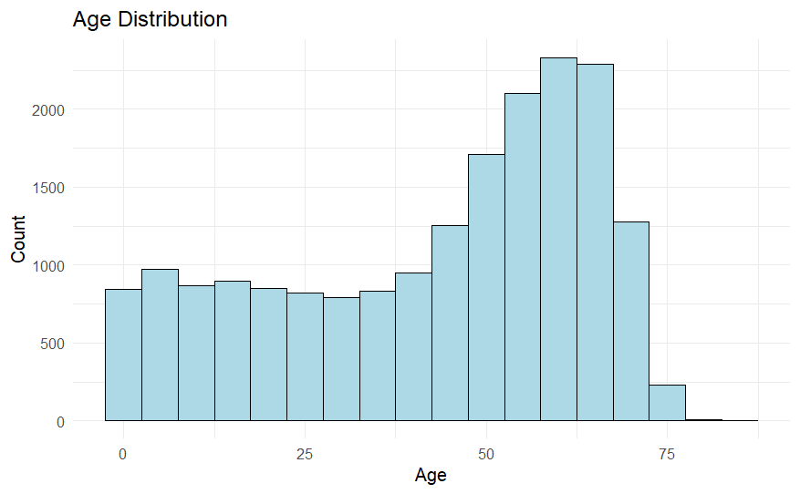

```r
# Age distribution
ggplot(working_df, aes(x = age)) +
  geom_histogram(binwidth = 5, fill = "lightblue", color = "black") +
  labs(title = "Age Distribution", x = "Age", y = "Count") +
  theme_minimal()
```

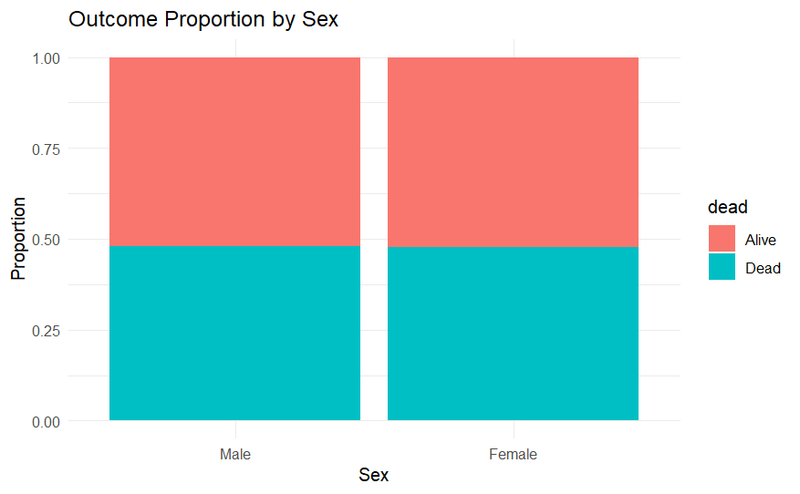

```r
# Proportion of survival outcome by sex
ggplot(working_df, aes(x = sex, fill = dead)) +
  geom_bar(position = "fill") +
  labs(title = "Outcome Proportion by Sex", x = "Sex", y = "Proportion") +
  theme_minimal()
```

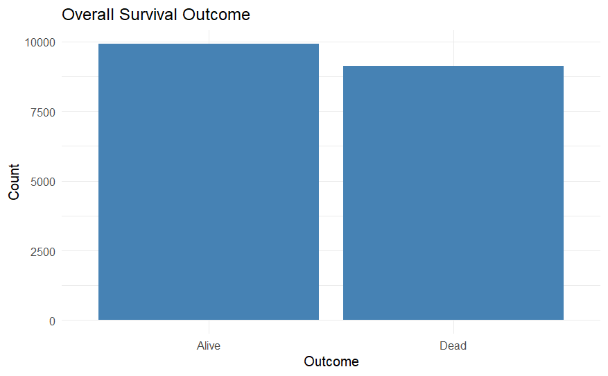

```r
# Overall outcome distribution
ggplot(working_df, aes(x = dead)) +
  geom_bar(fill = "steelblue") +
  labs(title = "Overall Survival Outcome", x = "Outcome", y = "Count") +
  theme_minimal()
```

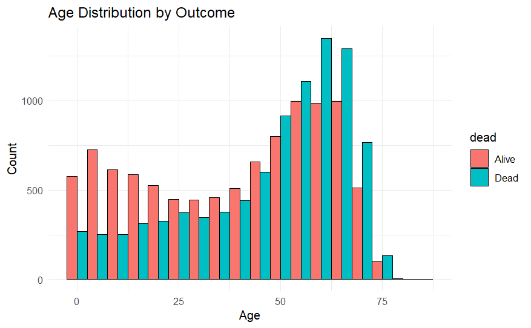

```r
# Age distribution by outcome
ggplot(working_df, aes(x = age, fill = dead)) +
  geom_histogram(position = "dodge", binwidth = 5, color = "black") +
  labs(title = "Age Distribution by Outcome", x = "Age", y = "Count") +
  theme_minimal()
```

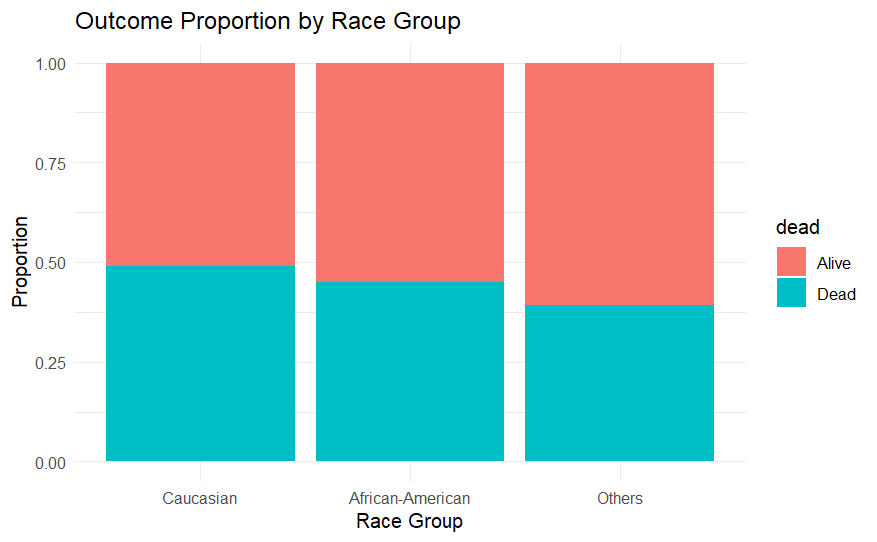

```r
# Race group by outcome
ggplot(working_df, aes(x = racegp, fill = dead)) +
  geom_bar(position = "fill") +
  labs(title = "Outcome Proportion by Race Group", x = "Race Group", y = "Proportion") +
  theme(axis.text.x = element_text(angle = 45, hjust = 1)) +
  theme_minimal()
```

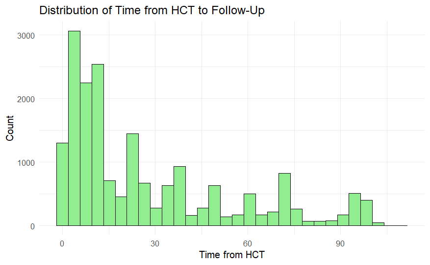

```r
# Time from HCT to death/last follow-up
ggplot(working_df, aes(x = intxsurv)) +
  geom_histogram(fill = "lightgreen", color = "black", bins = 30) +
  labs(title = "Distribution of Time from HCT to Follow-Up",
       x = "Time from HCT", y = "Count") +
  theme_minimal()
```

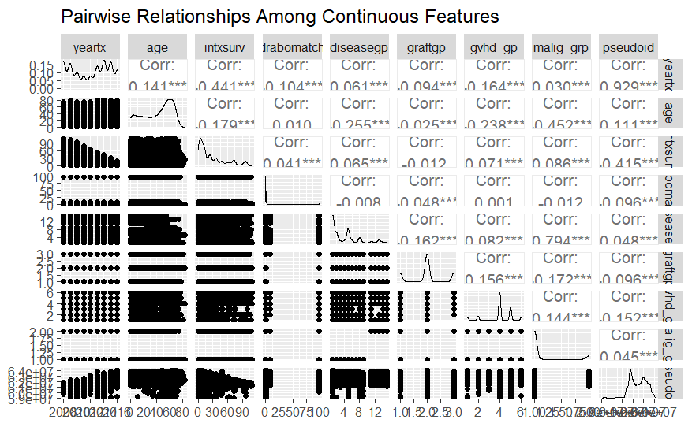

```r
#Correlation/Pair Plot among Continuous Features
numeric_vars <- working_df %>% select(where(is.numeric))
  ggpairs(numeric_vars) +
    ggtitle("Pairwise Relationships Among Continuous Features")
```

# 6. Data Splitting and Feature Selection

Split the dataset into training (70%) and testing (30%) sets and use the Boruta algorithm for feature selection.

```r
set.seed(123)  # For reproducibility
split <- initial_split(working_df, prop = 0.7)
training <- training(split)
testing  <- testing(split)

# Perform feature selection with Boruta
boruta.analysis <- Boruta(dead ~ ., data = training)
print(boruta.analysis)
```

```
Boruta performed 99 iterations in 13.63274 mins.
 22 attributes confirmed important: age, agvhd24, agvhd34, agvhdgp,
atgcampathgp and 17 more;
 5 attributes confirmed unimportant: drabomatch, drcmvgp, kidfunc,
sex, tma_event;
 2 tentative attributes left: karnofcat, priautogp;
```

```r
print(boruta.analysis$finalDecision)
```

```
      yeartx          sex     plsmpshi          age     intxsurv
   Confirmed     Rejected    Confirmed    Confirmed    Confirmed
  drabomatch      renfail    karnofcat    diseasegp atgcampathgp
    Rejected    Confirmed    Tentative    Confirmed    Confirmed
     graftgp       racegp      hctcigp      drcmvgp    priautogp
   Confirmed    Confirmed    Confirmed     Rejected    Tentative
  dworenfail       condgp      kidfunc      agvhd24      agvhd34
   Confirmed    Confirmed     Rejected    Confirmed    Confirmed
  dwoagvhd24   dwoagvhd34     death_gp      dnrtype      gvhd_gp
   Confirmed    Confirmed    Confirmed    Confirmed    Confirmed
   malig_grp      agvhdgp    tma_event     pseudoid
   Confirmed    Confirmed     Rejected    Confirmed
Levels: Tentative Confirmed Rejected
```

# 7. Logistic Regression Modeling

Fit a logistic regression model using selected predictors. Adjust the model formula based on domain expertise and Boruta results.

```r
model <- glm(dead ~ age + racegp + karnofcat + hctcigp +
               diseasegp + atgcampathgp + graftgp + drabomatch +
               kidfunc + condgp + malig_grp + yeartx + drcmvgp +
               priautogp + plsmpshi + intxsurv + renfail + dnrtype + agvhdgp,
             data = training,
             family = binomial)

# Model coefficients as odds ratios with 95% confidence intervals
odds_ratios <- exp(coef(model))
conf_int <- exp(confint(model))
results <- data.frame(Estimate = odds_ratios,
                      CI_Lower = conf_int[,1],
                      CI_Upper = conf_int[,2])
print(results)
```

|  | Estimate | CI_Lower | CI_Upper |
| --- | --- | --- | --- |
| (Intercept) | Inf | Inf | Inf |
| age | 1.0204819 | 1.0163462 | 1.0246600 |
| racegpAfrican-American | 1.0156420 | 0.8301342 | 1.2415194 |
| racegpOthers | 0.5156207 | 0.4160875 | 0.6376520 |
| karnofcat<90 | 1.0522546 | 0.9312796 | 1.1886686 |
| hctcigp1 | 1.2519330 | 1.0348618 | 1.5138410 |
| hctcigp2 | 1.3160544 | 1.0844709 | 1.5964256 |
| hctcigp>=3 | 1.5457886 | 1.3323303 | 1.7942496 |
| diseasegp | 0.9723507 | 0.9467343 | 0.9985920 |
| atgcampathgpATG alone | 3.8458239 | 0.1441812 | 200.4216459 |

[output cut: 28 more lines]

```r
NA
```

# 8. Model Evaluation

Evaluate the model on the testing set with prediction probabilities, confusion matrix, ROC curve, and assess multicollinearity with VIF.

```r
# Predict probabilities on testing data
testing$predicted_prob <- predict(model, newdata = testing, type = "response")

# Convert probabilities to binary predictions using a cutoff of 0.5
testing$predicted_class <- ifelse(testing$predicted_prob >= 0.5, "Dead", "Alive")
testing$predicted_class <- factor(testing$predicted_class, levels = c("Alive", "Dead"))

# Confusion Matrix
conf_matrix <- confusionMatrix(testing$predicted_class, testing$dead)
print(conf_matrix)
```

```
Confusion Matrix and Statistics

          Reference
Prediction Alive Dead
     Alive  2772  371
     Dead    258 2313

               Accuracy : 0.8899
                 95% CI : (0.8815, 0.8979)
    No Information Rate : 0.5303
    P-Value [Acc > NIR] : < 2.2e-16

                  Kappa : 0.7785

 Mcnemar's Test P-Value : 7.98e-06

            Sensitivity : 0.9149
            Specificity : 0.8618
         Pos Pred Value : 0.8820
         Neg Pred Value : 0.8996
             Prevalence : 0.5303
         Detection Rate : 0.4851
   Detection Prevalence : 0.5501
      Balanced Accuracy : 0.8883

       'Positive' Class : Alive
```

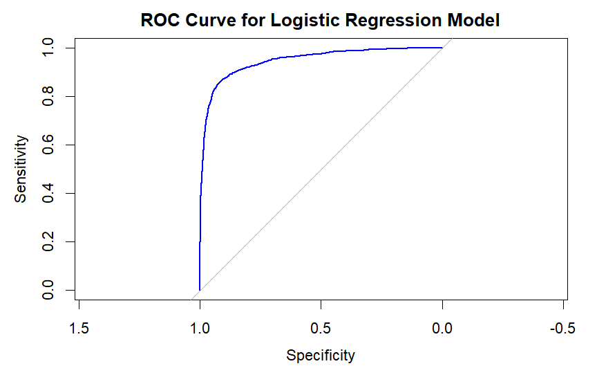

```r
# ROC Curve and AUC
roc_curve <- roc(testing$dead, testing$predicted_prob)
plot(roc_curve, col = "blue", main = "ROC Curve for Logistic Regression Model")
```

```r
auc_value <- auc(roc_curve)
print(auc_value)
```

```
Area under the curve: 0.9474
```

```r
# Evaluate multicollinearity with VIF
vif_values <- vif(model)
print(vif_values)
```

```
                 GVIF Df GVIF^(1/(2*Df))
age          2.153652  1        1.467533
racegp       1.246783  2        1.056690
karnofcat    1.078136  1        1.038333
hctcigp      1.239217  3        1.036393
diseasegp    2.438301  1        1.561506
atgcampathgp 1.332516  3        1.049008
graftgp      2.989011  1        1.728876
drabomatch   1.207696  1        1.098952
kidfunc      1.022607  1        1.011240
condgp       1.645716  3        1.086574
malig_grp    2.858446  1        1.690694
yeartx       2.873077  1        1.695015
drcmvgp      1.159828  3        1.025020
priautogp    1.113658  1        1.055300
plsmpshi     1.031945  1        1.015847
intxsurv     2.682255  1        1.637759
renfail      1.043376  1        1.021458
dnrtype      5.615136  9        1.100604
agvhdgp      1.061040  2        1.014923
```

# 9. Model Refinement and Risk Stratification

Use stepwise selection for model refinement and stratify patients into risk groups based on predicted probabilities.

```r
# Stepwise selection to refine the model
step_model <- step(model, direction = "both")
```

```
Start:  AIC=7677.06
dead ~ age + racegp + karnofcat + hctcigp + diseasegp + atgcampathgp +
    graftgp + drabomatch + kidfunc + condgp + malig_grp + yeartx +
    drcmvgp + priautogp + plsmpshi + intxsurv + renfail + dnrtype +
    agvhdgp

               Df Deviance     AIC
- atgcampathgp  3   7602.7  7672.7
- condgp        3   7603.5  7673.5
- graftgp       1   7601.2  7675.2
- drabomatch    1   7601.2  7675.2
- plsmpshi      1   7601.4  7675.4
- karnofcat     1   7601.7  7675.7
- priautogp     1   7602.7  7676.7
<none>              7601.1  7677.1
- kidfunc       1   7603.3  7677.3
- diseasegp     1   7605.3  7679.3
- drcmvgp       3   7616.6  7686.6
- dnrtype       9   7628.7  7686.7
- malig_grp     1   7620.5  7694.5
- hctcigp       3   7634.3  7704.3
- racegp        2   7640.6  7712.6
- age           1   7698.6  7772.6
- agvhdgp       2   7710.2  7782.2
- renfail       1   7815.7  7889.7
- yeartx        1  11503.9 11577.9
- intxsurv      1  15424.8 15498.8

Step:  AIC=7672.67
dead ~ age + racegp + karnofcat + hctcigp + diseasegp + graftgp +
    drabomatch + kidfunc + condgp + malig_grp + yeartx + drcmvgp +
    priautogp + plsmpshi + intxsurv + renfail + dnrtype + agvhdgp

               Df Deviance     AIC
- condgp        3   7605.0  7669.0
- graftgp       1   7602.8  7670.8
- drabomatch    1   7602.8  7670.8
- plsmpshi      1   7603.0  7671.0
- karnofcat     1   7603.4  7671.4
- priautogp     1   7604.3  7672.3
```

[output cut: 160 more lines]

```
+ plsmpshi      1   7607.5  7663.5
+ drabomatch    1   7607.7  7663.7
+ graftgp       1   7607.7  7663.7
+ condgp        3   7605.6  7665.6
+ atgcampathgp  3   7606.3  7666.3
- drcmvgp       3   7623.0  7671.0
- dnrtype       9   7635.5  7671.5
- malig_grp     1   7634.5  7686.5
- hctcigp       3   7644.9  7692.9
- racegp        2   7648.8  7698.8
- agvhdgp       2   7718.7  7768.7
- age           1   7746.9  7798.9
- renfail       1   7825.8  7877.8
- yeartx        1  11584.2 11636.2
- intxsurv      1  15520.0 15572.0
```

```r
summary(step_model)
```

```
Call:
glm(formula = dead ~ age + racegp + hctcigp + diseasegp + kidfunc +
    malig_grp + yeartx + drcmvgp + intxsurv + renfail + dnrtype +
    agvhdgp, family = binomial, data = training)

Coefficients:
                                      Estimate Std. Error z value Pr(>|z|)
(Intercept)                          1.904e+03  4.387e+01  43.397  < 2e-16
age                                  2.067e-02  1.786e-03  11.578  < 2e-16
racegpAfrican-American               8.338e-03  1.023e-01   0.082 0.935034
racegpOthers                        -6.705e-01  1.081e-01  -6.204 5.49e-10
hctcigp1                             2.298e-01  9.679e-02   2.374 0.017577
hctcigp2                             2.789e-01  9.832e-02   2.837 0.004559
hctcigp>=3                           4.536e-01  7.495e-02   6.051 1.44e-09
diseasegp                           -2.472e-02  1.292e-02  -1.914 0.055616
kidfuncNormal kidney function       -1.602e-01  1.059e-01  -1.512 0.130578
malig_grp                           -9.445e-01  1.841e-01  -5.132 2.87e-07
yeartx                              -9.443e-01  2.177e-02 -43.382  < 2e-16
drcmvgp+/-                          -1.426e-01  1.047e-01  -1.362 0.173123
drcmvgp-/+                           5.993e-02  7.526e-02   0.796 0.425849
drcmvgp-/-                          -2.239e-01  8.022e-02  -2.791 0.005262
intxsurv                            -1.334e-01  2.607e-03 -51.190  < 2e-16
renfailYes                           2.069e+00  1.578e-01  13.113  < 2e-16
dnrtypeOther related                 5.668e-02  1.011e-01   0.561 0.574869
dnrtypeWell-matched unrelated       -3.819e-02  7.721e-02  -0.495 0.620835
dnrtypePartially-matched unrelated   2.238e-01  1.205e-01   1.857 0.063361
dnrtypeMis-matched unrelated         4.687e-01  5.511e-01   0.850 0.395065
dnrtypeUnrelated, HLA match unknown -2.066e-01  2.646e-01  -0.781 0.434890
dnrtypeCB 6/6                        1.421e-01  2.258e-01   0.629 0.529366
dnrtypeCB 5/6                        2.799e-01  1.311e-01   2.136 0.032715
dnrtypeCB <=4/6                      3.612e-02  1.330e-01   0.271 0.786013
dnrtypeCB, HLA match unknown        -8.746e-01  2.431e-01  -3.597 0.000322
agvhdgpGrade 2                       1.960e-01  6.971e-02   2.812 0.004928
agvhdgpGrade 3-4                     8.774e-01  8.403e-02  10.440  < 2e-16

(Intercept)                         ***
age                                 ***
racegpAfrican-American
racegpOthers                        ***
hctcigp1                            *
```

[output cut: 17 more lines]

```
dnrtypeCB 5/6                       *
dnrtypeCB <=4/6
dnrtypeCB, HLA match unknown        ***
agvhdgpGrade 2                      **
agvhdgpGrade 3-4                    ***
---
Signif. codes:  0 ‘***’ 0.001 ‘**’ 0.01 ‘*’ 0.05 ‘.’ 0.1 ‘ ’ 1

(Dispersion parameter for binomial family taken to be 1)

    Null deviance: 18462.4  on 13329  degrees of freedom
Residual deviance:  7607.8  on 13303  degrees of freedom
AIC: 7661.8

Number of Fisher Scoring iterations: 6
```

```r
# Calculate risk score and categorize risk groups
testing$risk_score <- predict(model, newdata = testing, type = "response")
testing$risk_category <- cut(testing$risk_score, breaks = c(0, 0.3, 0.6, 1),
                             labels = c("Low Risk", "Medium Risk", "High Risk"))
table(testing$risk_category)
```

```
   Low Risk Medium Risk   High Risk
       2617         719        2378
```

# 10. Visualization of Key Relationships

Generate additional plots to illustrate relationships between variables and outcomes

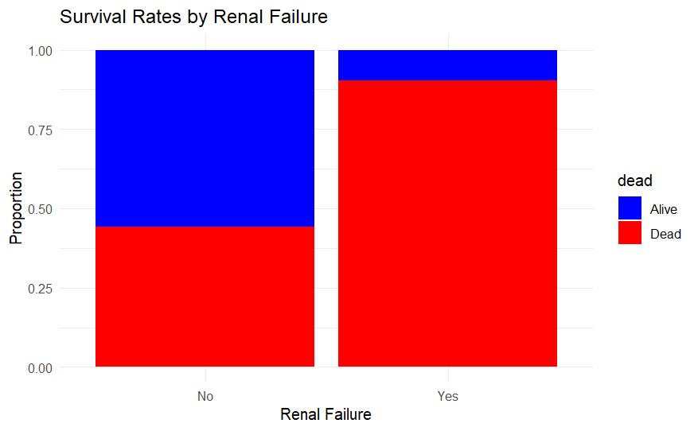

```r
# Bar plot: Renal failure and survival status
ggplot(training, aes(x = renfail, fill = dead)) +
  geom_bar(position = "fill") +
  labs(title = "Survival Rates by Renal Failure",
       x = "Renal Failure", y = "Proportion") +
  scale_fill_manual(values = c("blue", "red")) +
  theme_minimal()
```

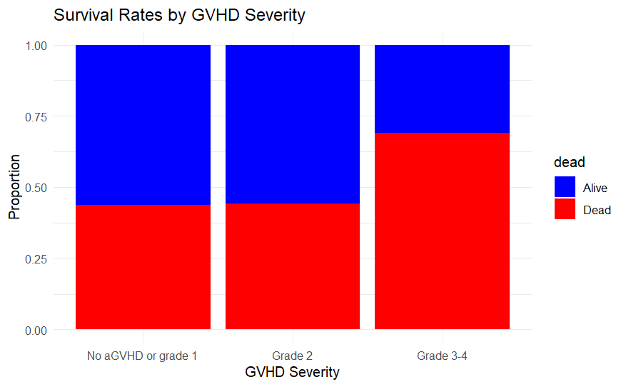

```r
# Bar plot: GVHD severity and survival status
ggplot(training, aes(x = agvhdgp, fill = dead)) +
  geom_bar(position = "fill") +
  labs(title = "Survival Rates by GVHD Severity",
       x = "GVHD Severity", y = "Proportion") +
  scale_fill_manual(values = c("blue", "red")) +
  theme_minimal()
```

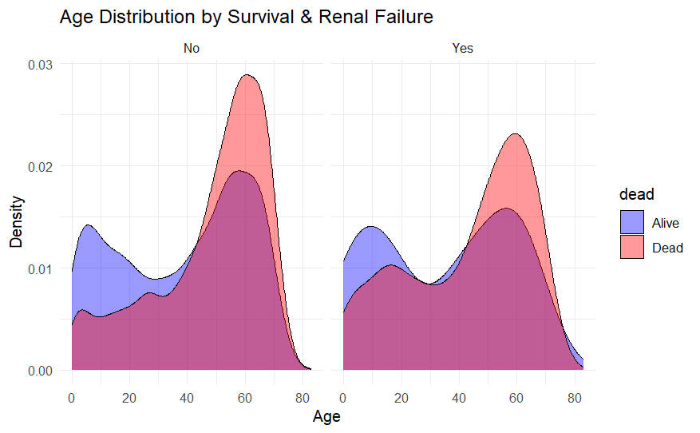

```r
# Density plot: Age distribution by survival and renal failure
ggplot(training, aes(x = age, fill = dead)) +
  geom_density(alpha = 0.4) +
  facet_wrap(~ renfail) +
  labs(title = "Age Distribution by Survival & Renal Failure",
       x = "Age", y = "Density") +
  scale_fill_manual(values = c("blue", "red")) +
  theme_minimal()
```

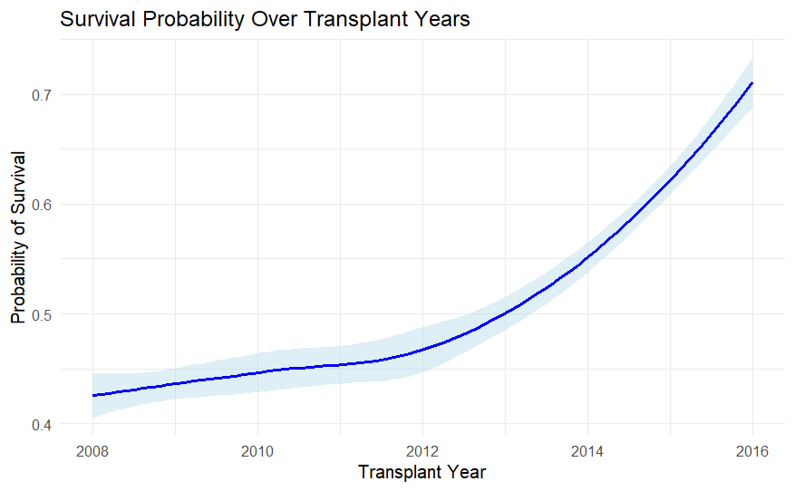

```r
# Survival probability over transplant year
ggplot(training, aes(x = yeartx, y = as.numeric(dead == "Alive"))) +
  geom_smooth(method = "loess", color = "blue", fill = "lightblue") +
  labs(title = "Survival Probability Over Transplant Years",
       x = "Transplant Year", y = "Probability of Survival") +
  theme_minimal()
```

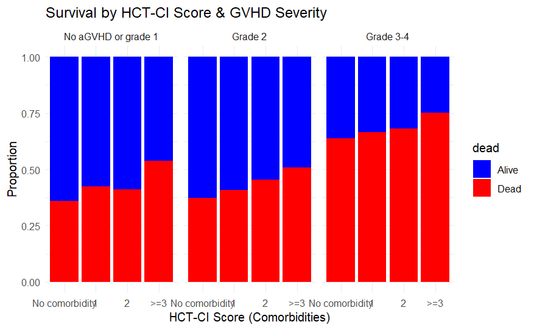

```r
# Bar plot: HCT-CI and GVHD severity with survival
ggplot(training, aes(x = hctcigp, fill = dead)) +
  geom_bar(position = "fill") +
  facet_wrap(~ agvhdgp) +
  labs(title = "Survival by HCT-CI Score & GVHD Severity",
       x = "HCT-CI Score (Comorbidities)", y = "Proportion") +
  scale_fill_manual(values = c("blue", "red")) +
  theme_minimal()
```

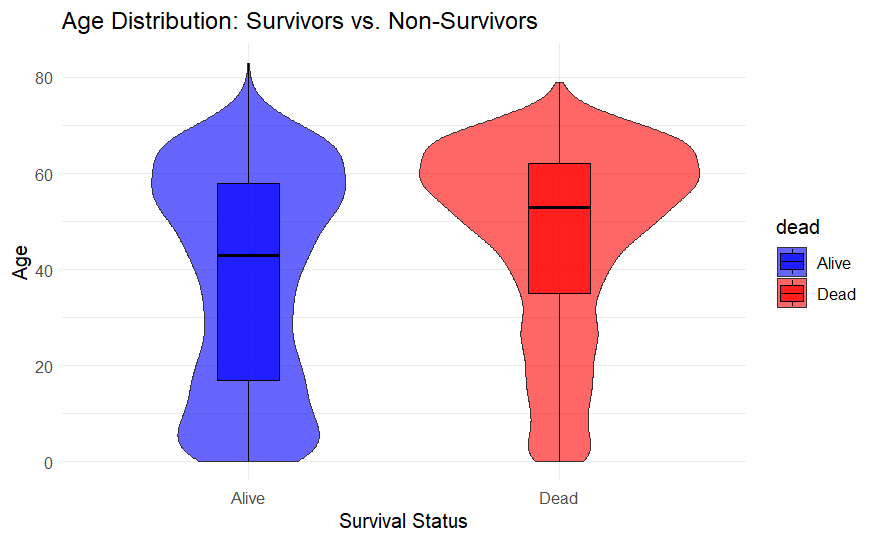

```r
# Violin plot: Age distribution by survival status
ggplot(training, aes(x = dead, y = age, fill = dead)) +
  geom_violin(alpha = 0.6) +
  geom_boxplot(width = 0.2, color = "black", alpha = 0.7) +
  labs(title = "Age Distribution: Survivors vs. Non-Survivors",
       x = "Survival Status", y = "Age") +
  scale_fill_manual(values = c("blue", "red")) +
  theme_minimal()
```

# 11. Assessing Feature Correlations & Variable Effects

Plot a heatmap of the correlation matrix among numeric features and a forest plot to visualize predictor effects.

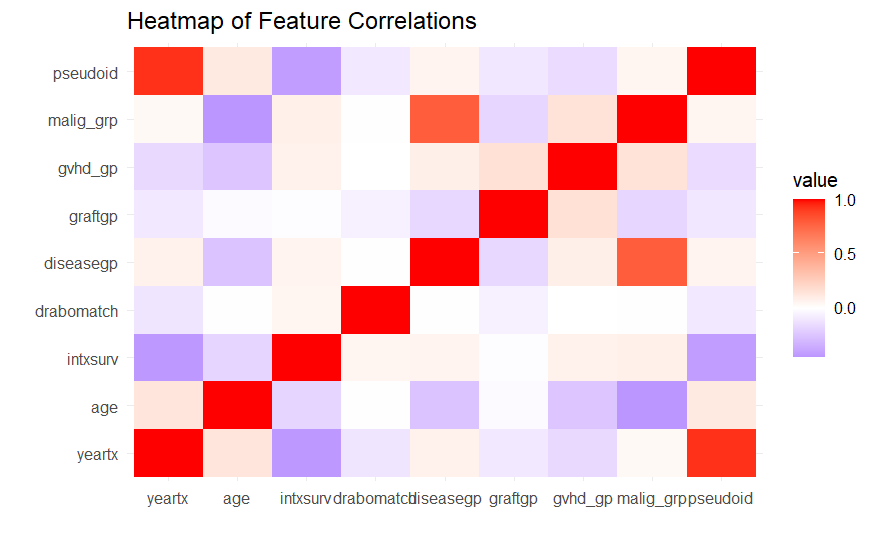

```r
# Correlation heatmap for numeric features
cor_matrix <- cor(training %>% select(where(is.numeric)), use = "complete.obs")
melted_cor <- melt(cor_matrix)
ggplot(melted_cor, aes(Var1, Var2, fill = value)) +
  geom_tile() +
  scale_fill_gradient2(low = "blue", high = "red", mid = "white", midpoint = 0) +
  labs(title = "Heatmap of Feature Correlations", x = "", y = "") +
  theme_minimal()
```

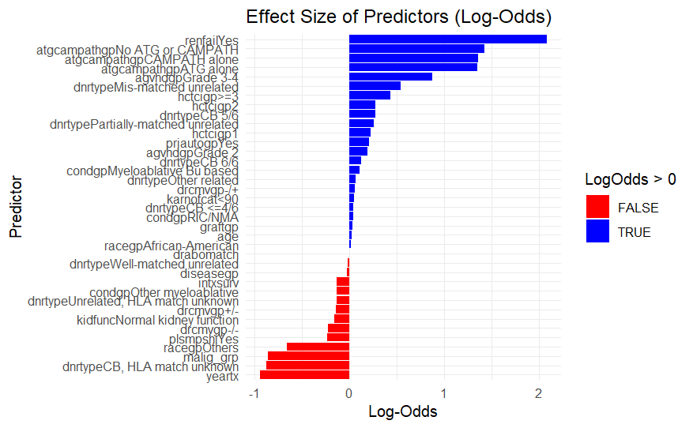

```r
# Forest plot: Odds ratios of predictors
# Extract coefficients and confidence intervals, then remove intercept
coef_df <- data.frame(
  Predictor = names(coef(model)),
  LogOdds = coef(model)
) %>%
  filter(Predictor != "(Intercept)") %>%
  arrange(LogOdds)

ggplot(coef_df, aes(x = reorder(Predictor, LogOdds), y = LogOdds, fill = LogOdds > 0)) +
  geom_col() +
  coord_flip() +
  scale_fill_manual(values = c("red", "blue")) +
  labs(title = "Effect Size of Predictors (Log-Odds)",
       x = "Predictor", y = "Log-Odds") +
  theme_minimal()
```

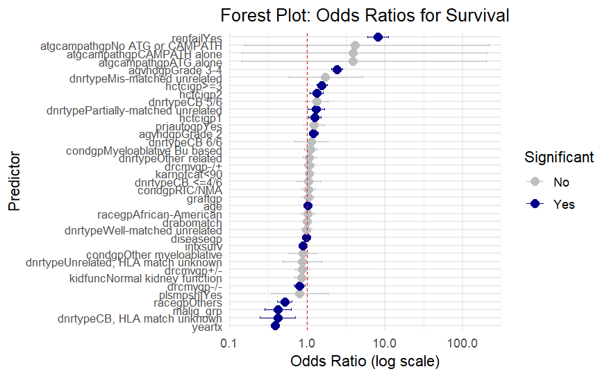

```r
# Forest plot with Odds Ratios and 95% CI
odds_ratios <- exp(coef(model))
conf_intervals <- exp(confint(model))
forest_df <- data.frame(
  Predictor = names(odds_ratios),
  OR = odds_ratios,
  Lower_CI = conf_intervals[, 1],
  Upper_CI = conf_intervals[, 2]
) %>%
  filter(Predictor != "(Intercept)") %>%
  arrange(OR) %>%
  mutate(
    # Mark significance if CI does not cross 1
    Significant = ifelse(Lower_CI > 1 | Upper_CI < 1, "Yes", "No")
  )

# Plot
ggplot(forest_df, aes(x = OR, y = fct_reorder(Predictor, OR))) +
  geom_point(aes(color = Significant), size = 3) +
  geom_errorbarh(aes(xmin = Lower_CI, xmax = Upper_CI, color = Significant), height = 0.3) +
  geom_vline(xintercept = 1, linetype = "dashed", color = "red") +
  scale_x_log10() +  # Log scale for better spacing
  scale_color_manual(values = c("Yes" = "darkblue", "No" = "gray")) +
  labs(
    title = "Forest Plot: Odds Ratios for Survival",
    x = "Odds Ratio (log scale)",
    y = "Predictor",
    color = "Significant"
  ) +
  theme_minimal(base_size = 12) +
  theme(
    axis.text.y = element_text(size = 9),
    plot.title = element_text(hjust = 0.5)
  )
```